/*1. Run a simple bivariate regression, and interpret your results. (Did the results fit your expectations? Why? Why not?) 2. Add an additional variable that might mediate or partly "explain" the initial association from that simple regression above -- and explain your results. Did it work out? Yes? No? 3. Run another multiple regression. Tell me how you expect your dependent variable to be affected by the independent variables. Interpret your results. 4. Now add another independent variable to that model in Question 3, specifically a set of dummy variables. Tell me why you added that new set of variables and what effect you expected them to have. Did they have an effect? Interpret that new model. */

# Lab #3

```python
Some preliminary set up code:
```

[output not shown]

```python
from __future__ import division
import pandas as pd
import numpy as np
import statsmodels.api as sm
import statsmodels.formula.api as smf
import os
import matplotlib.pyplot as plt
```

```python
os.chdir('C:/Users/gksfl/Documents/Data Analysis')
g=pd.read_csv("GSS.2006.csv")
g.head()
```

|  | vpsu | vstrat | adults | ballot | dateintv | famgen | form | formwt | gender1 | hompop | ... | away7 | gender14 | old14 | relate14 | relhh14 | relhhd14 | relsp14 | where12 | where6 | where7 |
| --- | --- | --- | --- | --- | --- | --- | --- | --- | --- | --- | --- | --- | --- | --- | --- | --- | --- | --- | --- | --- | --- |
| 0 | 1 | 1957 | 1 | 3 | 316 | 2 | 1 | 1 | 2 | 3 | ... | NaN | NaN | NaN | NaN | NaN | NaN | NaN | NaN | NaN | NaN |
| 1 | 1 | 1957 | 2 | 2 | 630 | 1 | 2 | 1 | 2 | 2 | ... | NaN | NaN | NaN | NaN | NaN | NaN | NaN | NaN | NaN | NaN |
| 2 | 1 | 1957 | 2 | 2 | 314 | 2 | 1 | 1 | 2 | 2 | ... | NaN | NaN | NaN | NaN | NaN | NaN | NaN | NaN | NaN | NaN |
| 3 | 1 | 1957 | 1 | 1 | 313 | 1 | 2 | 1 | 2 | 1 | ... | NaN | NaN | NaN | NaN | NaN | NaN | NaN | NaN | NaN | NaN |
| 4 | 1 | 1957 | 3 | 1 | 322 | 2 | 2 | 1 | 2 | 3 | ... | NaN | NaN | NaN | NaN | NaN | NaN | NaN | NaN | NaN | NaN |

5 rows × 1261 columns

```python
g.columns
```

```
Index(['vpsu', 'vstrat', 'adults', 'ballot', 'dateintv', 'famgen', 'form',
       'formwt', 'gender1', 'hompop',
       ...
       'away7', 'gender14', 'old14', 'relate14', 'relhh14', 'relhhd14',
       'relsp14', 'where12', 'where6', 'where7'],
      dtype='object', length=1261)
```

# 1-- Run a simple bivariate regression, and interpret your results. (Did the results fit your expectations? Why? Why not?)

## I want to see if people who has more family income are more likely to think that it is important to turn to family for help with his/her situation on average.

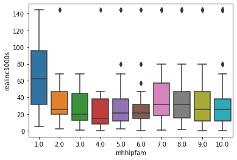

```python
g['realinc1000s'] = (g['realinc'])/1000 ## turn income into 1000s of dollars for ease of interpretation

 ## mhhlpfam asked "How important you think each would be for him/her to use in order to get help with (his/her) situation: A. Turn to family for help" with 1 being not at all important to 10 being very important.


## Look at the plot of average income by how important one feels to turn to family for help.
import seaborn as sns
sns.boxplot(x="mhhlpfam", y="realinc1000s",
                        data=g)
```

# 2. Add an additional variable that might mediate or partly "explain" the initial association from that simple regression above -- and explain your results. Did it work out? Yes? No?

# Additional variable that might partly explain this association is that being able to reach out to family for help would depend on his or her family culture, number of members of household and their personality. So I looked at timeoff, to what extent the respondent finds it difficult to take an hour or two off during work hours, to take care of personal or family matters, 1 being not difficult at all to 4 being very difficult. The higher the score, the more difficult people felt about taking care of personal or family matters.

```python
gg = g.dropna(subset = ["timeoff"])

lm_rep = smf.ols(formula = 'mhhlpfam~realinc1000s', data = gg).fit()
print (lm_rep.summary())
```

```
                            OLS Regression Results
==============================================================================
Dep. Variable:               mhhlpfam   R-squared:                       0.006
Model:                            OLS   Adj. R-squared:                  0.004
Method:                 Least Squares   F-statistic:                     4.732
Date:                Tue, 01 Jun 2021   Prob (F-statistic):             0.0299
Time:                        10:23:15   Log-Likelihood:                -1841.2
No. Observations:                 837   AIC:                             3686.
Df Residuals:                     835   BIC:                             3696.
Df Model:                           1
Covariance Type:            nonrobust
================================================================================
                   coef    std err          t      P>|t|      [0.025      0.975]
--------------------------------------------------------------------------------
Intercept        8.7171      0.114     76.237      0.000       8.493       8.942
realinc1000s    -0.0048      0.002     -2.175      0.030      -0.009      -0.000
==============================================================================
Omnibus:                      230.840   Durbin-Watson:                   1.974
Prob(Omnibus):                  0.000   Jarque-Bera (JB):              468.849
Skew:                          -1.591   Prob(JB):                    1.55e-102
Kurtosis:                       4.820   Cond. No.                         79.1
==============================================================================

Notes:
[1] Standard Errors assume that the covariance matrix of the errors is correctly specified.
```